# Perbandingan Kinerja Random Forest dan Support Vector Machine dalam Klasifikasi Rekomendasi Destinasi Wisata Bali

kamelia

2026-09-02

# Pendahuluan

Sektor pariwisata merupakan salah satu sektor strategis yang berperan dalam pembangunan ekonomi Indonesia. Bali menjadi salah satu destinasi wisata unggulan dengan jumlah kunjungan wisatawan yang terus meningkat. Pada Januari–Mei 2025, kunjungan wisatawan mancanegara ke Bali mencapai 2,64 juta kunjungan, meningkat 13,65% dibandingkan periode yang sama tahun sebelumnya. Tingginya jumlah destinasi wisata di Bali memberikan banyak alternatif bagi wisatawan, tetapi sekaligus dapat menimbulkan information overload sehingga menyulitkan proses pemilihan destinasi sesuai kebutuhan dan preferensi. Oleh karena itu, diperlukan pendekatan berbasis data yang dapat membantu mengklasifikasikan destinasi wisata sebagai rekomendasi atau tidak. Salah satu sumber informasi wisata yang dapat dimanfaatkan adalah Google Maps, yang menyediakan data user-generated content seperti rating, jumlah ulasan, lokasi, dan informasi destinasi. Data tersebut dapat dimanfaatkan dalam pendekatan machine learning untuk membangun model klasifikasi rekomendasi destinasi wisata. Support Vector Machine (SVM) merupakan salah satu metode klasifikasi yang memiliki kemampuan baik dalam menangani data dengan pola pemisahan yang kompleks. Sementara itu, Random Forest (RF) merupakan metode ensemble berbasis decision tree yang efektif dalam menangani data tabular dan dapat mengurangi risiko overfitting. Perbedaan karakteristik kedua metode tersebut menjadikannya relevan untuk dibandingkan pada data pariwisata

Penelitian ini membandingkan kinerja metode **Random Forest** dan **Support Vector Machine (SVM)** dalam mengklasifikasikan rekomendasi destinasi wisata di Bali berdasarkan atribut seperti kategori wisata, harga tiket masuk, jumlah rating, dan jarak dari bandara. Model dievaluasi pada tiga skema pembagian data: 90:10, 80:20, dan 70:30.

## Library yang Digunakan

```r
library(tidyverse)
library(caret)
library(e1071)
library(randomForest)
library(readxl)
library(rpart)
library(rpart.plot)
library(recipes)
library(themis)
```

# 1. Import dan Persiapan Data

```r
dataskripsi <- read_csv2("destinasi_wisata_bali.csv")
names(dataskripsi) <- make.names(names(dataskripsi))
head(dataskripsi)
```

```
## # A tibble: 6 × 8
##   nama_tempat_wisata   kategori rating kabupaten_kota jumlah_rating htm.domestik
##   <chr>                <chr>     <dbl> <chr>                  <dbl> <chr>
## 1 Tanah Lot            Budaya      4.6 Kota Denpasar         101523 Rp30.000
## 2 Taman Budaya Garuda… Rekreasi    4.5 Kabupaten Bad…         70182 Rp85.000
## 3 Mandala Suci Wenara… Alam        4.5 Kabupaten Gia…         57613 Rp90.000
## 4 Tegallalang Rice Te… Alam        4.4 Kabupaten Gia…         52316 Rp25.000
## 5 Pura Luhur Uluwatu   Budaya      4.6 Kabupaten Bad…         50742 Rp40.000
## 6 Pura Ulun Danu Bera… Alam        4.6 Kabupaten Bad…         49969 Rp50.000
## # ℹ 2 more variables: htm.internasional <chr>, jarak..km. <dbl>
```

## Membentuk Variabel Target

Variabel target `rekomendasi` dibentuk dari `rating`: destinasi dengan rating >= 4.5 dikategorikan **“Direkomendasikan”**, sisanya **“Tidak_Direkomendasikan”**.

```r
dataskripsi$rekomendasi <- ifelse(
  dataskripsi$rating >= 4.5,
  "Direkomendasikan",
  "Tidak_Direkomendasikan")

dataskripsi$rekomendasi <- as.factor(dataskripsi$rekomendasi)
table(dataskripsi$rekomendasi)
```

```
##
##       Direkomendasikan Tidak_Direkomendasikan
##                    224                     90
```

```r
names(dataskripsi)
```

```
## [1] "nama_tempat_wisata" "kategori"           "rating"
## [4] "kabupaten_kota"     "jumlah_rating"      "htm.domestik"
## [7] "htm.internasional"  "jarak..km."         "rekomendasi"
```

## Membersihkan Data

```r
# Menghapus variabel yang tidak digunakan
dataskripsi <- dataskripsi %>%
  select(
    -nama_tempat_wisata,
    -rating,
    -kabupaten_kota)

# Ubah variabel kategorik menjadi factor
dataskripsi$kategori <- as.factor(dataskripsi$kategori)

# Bersihkan format harga tiket masuk (HTM)
dataskripsi$htm.internasional <- gsub("Rp|\\.","",dataskripsi$htm.internasional)
dataskripsi$htm.internasional <- as.numeric(dataskripsi$htm.internasional)

dataskripsi$htm.domestik <- gsub("Rp|\\.","",dataskripsi$htm.domestik)
dataskripsi$htm.domestik <- as.numeric(dataskripsi$htm.domestik)

str(dataskripsi)
```

```
## tibble [314 × 6] (S3: tbl_df/tbl/data.frame)
##  $ kategori         : Factor w/ 3 levels "Alam","Budaya",..: 2 3 1 1 2 1 1 1 1 2 ...
##  $ jumlah_rating    : num [1:314] 101523 70182 57613 52316 50742 ...
##  $ htm.domestik     : num [1:314] 30000 85000 90000 25000 40000 50000 15000 0 30000 25000 ...
##  $ htm.internasional: num [1:314] 75000 125000 130000 25000 40000 75000 15000 0 30000 50000 ...
##  $ jarak..km.       : num [1:314] 26 11 36 49 21 66 22 4 33 56 ...
##  $ rekomendasi      : Factor w/ 2 levels "Direkomendasikan",..: 1 1 1 2 1 1 1 1 2 1 ...
```

```r
# Cek data hilang
sum(is.na(dataskripsi))
```

```
## [1] 0
```

```r
# Ringkasan statistik
summary(dataskripsi)
```

```
##      kategori   jumlah_rating       htm.domestik    htm.internasional
##  Alam    :163   Min.   :   505.0   Min.   :     0   Min.   :      0
##  Budaya  : 68   1st Qu.:   907.8   1st Qu.:     0   1st Qu.:      0
##  Rekreasi: 83   Median :  1647.0   Median : 15000   Median :  20000
##                 Mean   :  4889.2   Mean   : 46089   Mean   :  64127
##                 3rd Qu.:  3575.2   3rd Qu.: 40000   3rd Qu.:  60000
##                 Max.   :101523.0   Max.   :850000   Max.   :1000000
##    jarak..km.                     rekomendasi
##  Min.   :  2.00   Direkomendasikan      :224
##  1st Qu.: 21.00   Tidak_Direkomendasikan: 90
##  Median : 42.00
##  Mean   : 47.71
##  3rd Qu.: 68.00
##  Max.   :148.00
```

# 2. Exploratory Data Analysis (EDA)

## Distribusi Kategori Wisata

```r
table(dataskripsi$kategori)
```

```
##
##     Alam   Budaya Rekreasi
##      163       68       83
```

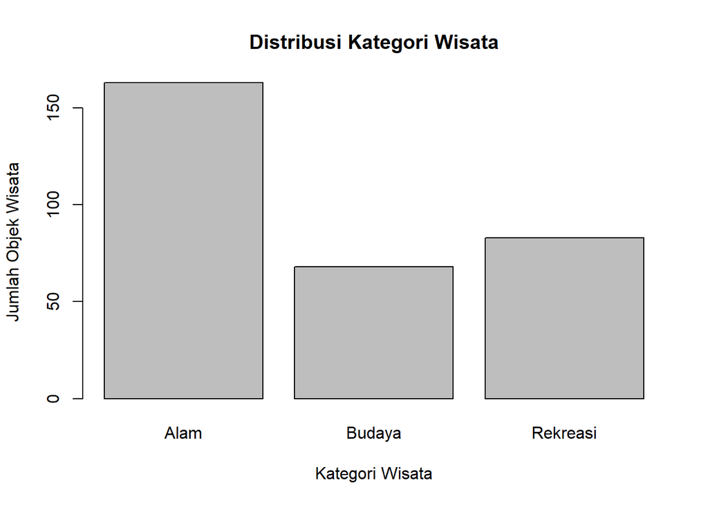

```r
barplot(
  table(dataskripsi$kategori),
  main = "Distribusi Kategori Wisata",
  xlab = "Kategori Wisata",
  ylab = "Jumlah Objek Wisata"
)
```

Berdasarkan gambar histogram Variabel kategori wisata data terdiri atas tiga kategori, yaitu Alam sebanyak 163 destinasi, Budaya sebanyak 68 destinasi, dan Rekreasi sebanyak 83 destinasi. Kategori Alam merupakan kategori dengan jumlah destinasi terbanyak, sedangkan kategori Budaya memiliki jumlah destinasi paling sedikit.

## Distribusi Variabel Prediktor Numerik

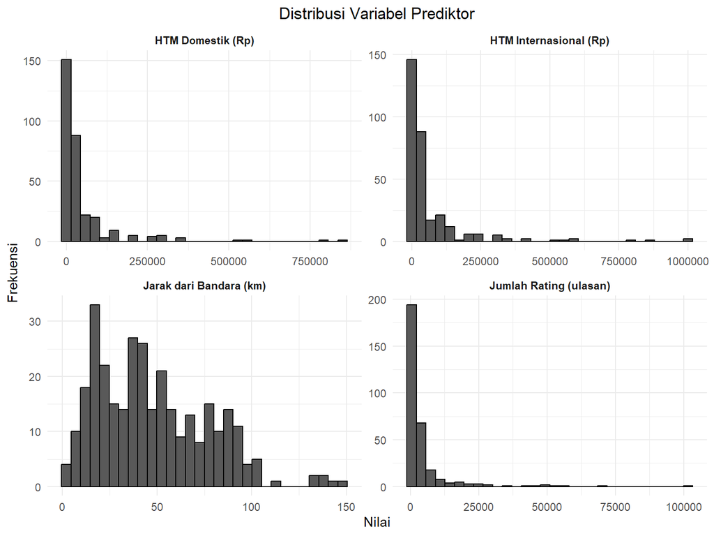

```r
dataskripsi %>%
  select(htm.internasional, htm.domestik, jumlah_rating, jarak..km.) %>%
  pivot_longer(cols = everything(), names_to = "Variabel", values_to = "Nilai") %>%
  mutate(
    Variabel = recode(
      Variabel,
      "htm.internasional" = "HTM Internasional (Rp)",
      "htm.domestik" = "HTM Domestik (Rp)",
      "jumlah_rating" = "Jumlah Rating (ulasan)",
      "jarak..km." = "Jarak dari Bandara (km)"
    )
  ) %>%
  ggplot(aes(x = Nilai)) +
  geom_histogram(bins = 30, color = "black") +
  facet_wrap(~Variabel, scales = "free") +
  labs(title = "Distribusi Variabel Prediktor", x = "Nilai", y = "Frekuensi") +
  theme_minimal() +
  theme(strip.text = element_text(face = "bold"), plot.title = element_text(hjust = 0.5))
```

variabel jumlah_rating, htm.domestik, dan htm.internasional memiliki sebaran yang mencong ke kanan dengan rentang nilai yang lebar serta terdapat beberapa observasi yang berada jauh di luar sebaran utama (outlier). Sebaliknya, variabel jarak tersebar lebih merata dan mendekati simetris. Kondisi ini menunjukkan bahwa skala dan tingkat sebaran antarvariabel sangat bervariasi dan tidak seragam.

```r
dataskripsi$observasi <- seq_len(nrow(dataskripsi))
```

## Fungsi Bantu: Metrik Evaluasi Lengkap

Fungsi ini dipakai berulang kali untuk menghitung akurasi, precision, recall, F1-score, dan specificity di setiap model.

```r
hitung_metrik_lengkap <- function(true, pred) {
  true <- factor(true, levels = levels(true))
  pred <- factor(pred, levels = levels(true))
  cm <- caret::confusionMatrix(pred, true)
  tab <- cm$table
  semua_kelas <- levels(true)

  hasil_kelas <- data.frame(
    Kelas = semua_kelas, Precision = 0, Recall = 0, F1 = 0, Specificity = 0
  )

  precision <- recall <- f1 <- specificity <- c()

  for (k in semua_kelas) {
    TP <- tab[k, k]
    FP <- sum(tab[k, ]) - TP
    FN <- sum(tab[, k]) - TP
    TN <- sum(tab) - TP - FP - FN

    p <- ifelse(TP + FP == 0, 0, TP / (TP + FP))
    r <- ifelse(TP + FN == 0, 0, TP / (TP + FN))
    f <- ifelse(p + r == 0, 0, 2 * p * r / (p + r))
    s <- ifelse(TN + FP == 0, 0, TN / (TN + FP))

    hasil_kelas[hasil_kelas$Kelas == k, 2:5] <- c(p, r, f, s)
    precision <- c(precision, p); recall <- c(recall, r)
    f1 <- c(f1, f); specificity <- c(specificity, s)
  }

  hasil_macro <- data.frame(
    Accuracy = as.numeric(cm$overall["Accuracy"]),
    Precision = mean(precision), Recall = mean(recall),
    F1 = mean(f1), Specificity = mean(specificity)
  )

  list(per_kelas = hasil_kelas, macro = hasil_macro)
}
```

# 3. Random Forest

## 3.1 Split 90:10

### Split Data dan SMOTE

```r
set.seed(26)
index <- createDataPartition(dataskripsi$rekomendasi, p = 0.9, list = FALSE)

data_train_rf <- dataskripsi[index, ]
data_test_rf  <- dataskripsi[-index, ]

train_rf <- data_train_rf %>% select(-observasi)
test_rf  <- data_test_rf %>% select(-observasi)

# SMOTE pada data training
set.seed(26)
rec_smotenc <- recipe(rekomendasi ~ ., data = train_rf) %>% step_smotenc(rekomendasi)
train_rf_smotenc <- prep(rec_smotenc) %>% bake(new_data = NULL)

table(train_rf$rekomendasi)
```

```
##
##       Direkomendasikan Tidak_Direkomendasikan
##                    202                     81
```

```r
table(train_rf_smotenc$rekomendasi)
```

```
##
##       Direkomendasikan Tidak_Direkomendasikan
##                    202                    202
```

```r
train_x_rf <- train_rf_smotenc %>% select(-rekomendasi)
train_y_rf <- train_rf_smotenc$rekomendasi
test_x_rf  <- test_rf %>% select(-rekomendasi)
test_y_rf  <- test_rf$rekomendasi
```

### Tuning Parameter

```r
mtry_list     <- c(1, 2, 5)
ntree_list    <- c(50, 80, 100, 150, 200)
nodesize_list <- c(3, 5, 7, 10, 15)
maxnodes_list <- c(10, 20, 50, 70, 100, 150)

hasil_tuning_90 <- data.frame(
  mtry = integer(), ntree = integer(), nodesize = integer(),
  maxnodes = integer(), accuracy = numeric(), stringsAsFactors = FALSE
)

set.seed(26)
for (m in mtry_list) {
  for (nt in ntree_list) {
    for (ns in nodesize_list) {
      for (mx in maxnodes_list) {
        model_temp <- randomForest(
          rekomendasi ~ ., data = train_rf_smotenc,
          mtry = m, ntree = nt, nodesize = ns, maxnodes = mx
        )
        pred_temp <- predict(model_temp, newdata = test_rf, type = "class")
        acc_temp <- confusionMatrix(pred_temp, test_y_rf)$overall["Accuracy"]
        hasil_tuning_90 <- rbind(
          hasil_tuning_90,
          data.frame(mtry = m, ntree = nt, nodesize = ns, maxnodes = mx, accuracy = acc_temp)
        )
      }
    }
  }
}

best_result_90 <- hasil_tuning_90[which.max(hasil_tuning_90$accuracy), ]
best_result_90
```

```
##             mtry ntree nodesize maxnodes  accuracy
## Accuracy152    2    50        3       50 0.8064516
```

### Model Final

```r
set.seed(26)
model_rf_90 <- randomForest(
  x = train_x_rf, y = train_y_rf,
  mtry = 2, ntree = 50, nodesize = 3, maxnodes = 50,
  importance = TRUE, keep.inbag = TRUE
)
model_rf_90
```

```
##
## Call:
##  randomForest(x = train_x_rf, y = train_y_rf, ntree = 50, mtry = 2,      nodesize = 3, maxnodes = 50, importance = TRUE, keep.inbag = TRUE)
##                Type of random forest: classification
##                      Number of trees: 50
## No. of variables tried at each split: 2
##
##         OOB estimate of  error rate: 28.96%
## Confusion matrix:
##                        Direkomendasikan Tidak_Direkomendasikan class.error
## Direkomendasikan                    146                     56   0.2772277
## Tidak_Direkomendasikan               61                    141   0.3019802
```

### Ilustrasi Salah Satu Pohon dalam Random Forest

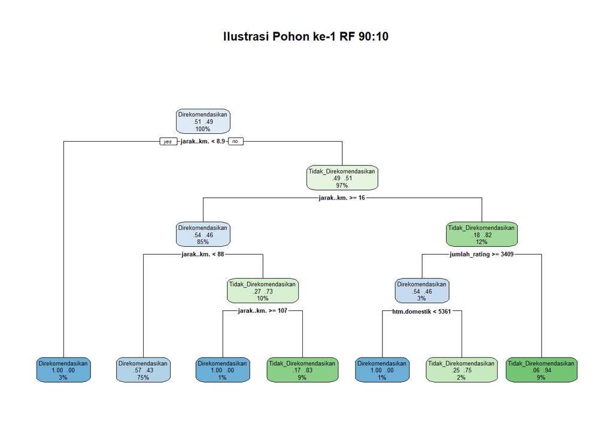

```r
train_rf_smotenc$observasi <- seq_len(nrow(train_rf_smotenc))

inbag_tree1_90 <- model_rf_90$inbag[, 1]
idx_bootstrap_tree1_90 <- rep(train_rf_smotenc$observasi, times = inbag_tree1_90)
bootstrap_tree1_90 <- train_rf_smotenc[match(idx_bootstrap_tree1_90, train_rf_smotenc$observasi), ]

tree_cart_boot1_90 <- rpart(
  rekomendasi ~ ., data = bootstrap_tree1_90 %>% select(-observasi),
  method = "class", parms = list(split = "information"),
  control = rpart.control(cp = 0, minsplit = 2, minbucket = 1, maxdepth = 4)
)

rpart.plot(tree_cart_boot1_90, type = 2, extra = 104, fallen.leaves = TRUE,
           main = "Ilustrasi Pohon ke-1 RF 90:10")
```

### Evaluasi Model

```r
pred_train_rf_90 <- predict(model_rf_90, train_x_rf)
pred_test_rf_90  <- predict(model_rf_90, test_x_rf)

cm_train_rf_90 <- confusionMatrix(pred_train_rf_90, train_y_rf)
cm_test_rf_90  <- confusionMatrix(pred_test_rf_90, test_y_rf)

metrik_rf_train_90 <- hitung_metrik_lengkap(train_y_rf, pred_train_rf_90)
metrik_rf_test_90  <- hitung_metrik_lengkap(test_y_rf, pred_test_rf_90)

metrik_rf_test_90$per_kelas
```

```
##                    Kelas Precision    Recall        F1 Specificity
## 1       Direkomendasikan 0.7826087 0.8181818 0.8000000   0.4444444
## 2 Tidak_Direkomendasikan 0.5000000 0.4444444 0.4705882   0.8181818
```

```r
metrik_rf_test_90$macro
```

```
##    Accuracy Precision    Recall        F1 Specificity
## 1 0.7096774 0.6413043 0.6313131 0.6352941   0.6313131
```

Model RF pada data testing proporsi 90:10 memperoleh nilai accuracy sebesar 0,7097. Hal ini menunjukkan bahwa model mampu mengklasifikasikan 70,97% destinasi wisata sesuai dengan kelas aktualnya. Secara keseluruhan, model menghasilkan nilai macro average precision, F1 score, dan sensitivity masing-masing sebesar 0,6413 , 0,6353 dan 0, 6313. Hasil tersebut menunjukkan bahwa model memiliki kemampuan klasifikasi yang baik, terutama dalam mengenali destinasi wisata yang termasuk dalam kelas Direkomendasikan.

## 3.2 Split 80:20

```r
set.seed(26)
index80 <- createDataPartition(dataskripsi$rekomendasi, p = 0.8, list = FALSE)

data_train_rf80 <- dataskripsi[index80, ]
data_test_rf80  <- dataskripsi[-index80, ]

train_rf80 <- data_train_rf80 %>% select(-observasi)
test_rf80  <- data_test_rf80 %>% select(-observasi)

set.seed(26)
rec_smotenc80 <- recipe(rekomendasi ~ ., data = train_rf80) %>% step_smotenc(rekomendasi)
train_rf_smotenc80 <- prep(rec_smotenc80) %>% bake(new_data = NULL)

train_x_rf80 <- train_rf_smotenc80 %>% select(-rekomendasi)
test_x_rf80  <- test_rf80 %>% select(-rekomendasi)
train_y_rf80 <- train_rf_smotenc80$rekomendasi
test_y_rf80  <- test_rf80$rekomendasi

set.seed(26)
model_rf_80 <- randomForest(
  x = train_x_rf80, y = train_y_rf80,
  mtry = 2, ntree = 50, nodesize = 7, maxnodes = 70,
  importance = TRUE, keep.inbag = TRUE
)
model_rf_80
```

```
##
## Call:
##  randomForest(x = train_x_rf80, y = train_y_rf80, ntree = 50,      mtry = 2, nodesize = 7, maxnodes = 70, importance = TRUE,      keep.inbag = TRUE)
##                Type of random forest: classification
##                      Number of trees: 50
## No. of variables tried at each split: 2
##
##         OOB estimate of  error rate: 30.28%
## Confusion matrix:
##                        Direkomendasikan Tidak_Direkomendasikan class.error
## Direkomendasikan                    131                     49   0.2722222
## Tidak_Direkomendasikan               60                    120   0.3333333
```

```r
pred_train_rf_80 <- predict(model_rf_80, train_x_rf80)
pred_test_rf_80  <- predict(model_rf_80, test_x_rf80)

metrik_rf_train_80 <- hitung_metrik_lengkap(train_y_rf80, pred_train_rf_80)
metrik_rf_test_80  <- hitung_metrik_lengkap(test_y_rf80, pred_test_rf_80)

metrik_rf_test_80$per_kelas
```

```
##                    Kelas Precision    Recall        F1 Specificity
## 1       Direkomendasikan 0.7555556 0.7727273 0.7640449   0.3888889
## 2 Tidak_Direkomendasikan 0.4117647 0.3888889 0.4000000   0.7727273
```

```r
metrik_rf_test_80$macro
```

```
##    Accuracy Precision    Recall        F1 Specificity
## 1 0.6612903 0.5836601 0.5808081 0.5820225   0.5808081
```

Catatan: chunk grid tuning untuk split 80:20 dan 70:30 mengikuti pola yang sama seperti 90:10 di atas.

Model RF pada data testing proporsi 80:20 memperoleh nilai accuracy sebesar 0.6612. Hal ini menunjukkan bahwa model mampu mengklasifikasikan 66,12% destinasi wisata sesuai dengan kelas aktualnya. Secara keseluruhan, model menghasilkan nilai macro average precision, F1 score, dan sensitivity masing-masing sebesar 0.5836, 0.5820 dan 0.5808. Hasil tersebut menunjukkan bahwa model memiliki kemampuan klasifikasi yang baik, terutama dalam mengenali destinasi wisata yang termasuk dalam kelas Direkomendasikan

## 3.3 Split 70:30

```r
set.seed(26)
index70 <- createDataPartition(dataskripsi$rekomendasi, p = 0.7, list = FALSE)

data_train_rf70 <- dataskripsi[index70, ]
data_test_rf70  <- dataskripsi[-index70, ]

train_rf70 <- data_train_rf70 %>% select(-observasi)
test_rf70  <- data_test_rf70 %>% select(-observasi)

set.seed(26)
rec_smotenc70 <- recipe(rekomendasi ~ ., data = train_rf70) %>% step_smotenc(rekomendasi)
train_rf_smotenc70 <- prep(rec_smotenc70) %>% bake(new_data = NULL)

train_x_rf70 <- train_rf_smotenc70 %>% select(-rekomendasi)
test_x_rf70  <- test_rf70 %>% select(-rekomendasi)
train_y_rf70 <- train_rf_smotenc70$rekomendasi
test_y_rf70  <- test_rf70$rekomendasi

set.seed(26)
model_rf_70 <- randomForest(
  x = train_x_rf70, y = train_y_rf70,
  mtry = 1, ntree = 80, nodesize = 5, maxnodes = 50,
  importance = TRUE, keep.inbag = TRUE
)
model_rf_70
```

```
##
## Call:
##  randomForest(x = train_x_rf70, y = train_y_rf70, ntree = 80,      mtry = 1, nodesize = 5, maxnodes = 50, importance = TRUE,      keep.inbag = TRUE)
##                Type of random forest: classification
##                      Number of trees: 80
## No. of variables tried at each split: 1
##
##         OOB estimate of  error rate: 31.85%
## Confusion matrix:
##                        Direkomendasikan Tidak_Direkomendasikan class.error
## Direkomendasikan                    100                     57   0.3630573
## Tidak_Direkomendasikan               43                    114   0.2738854
```

```r
pred_train_rf_70 <- predict(model_rf_70, train_x_rf70)
pred_test_rf_70  <- predict(model_rf_70, test_x_rf70)

metrik_rf_train_70 <- hitung_metrik_lengkap(train_y_rf70, pred_train_rf_70)
metrik_rf_test_70  <- hitung_metrik_lengkap(test_y_rf70, pred_test_rf_70)

metrik_rf_test_70$per_kelas
```

```
##                    Kelas Precision    Recall        F1 Specificity
## 1       Direkomendasikan 0.7272727 0.7164179 0.7218045   0.3333333
## 2 Tidak_Direkomendasikan 0.3214286 0.3333333 0.3272727   0.7164179
```

```r
metrik_rf_test_70$macro
```

```
##   Accuracy Precision    Recall        F1 Specificity
## 1 0.606383 0.5243506 0.5248756 0.5245386   0.5248756
```

Berdasarkan hasil evaluasi pada data testing, model Random Forest dengan skema pembagian data 70:30 menghasilkan nilai accuracy sebesar 60,64%, precision sebesar 52,44%, recall sebesar 52,49%, F1-score sebesar 52,45%, dan specificity sebesar 52,49%. Nilai accuracy yang diperoleh menunjukkan bahwa model mampu mengklasifikasikan dengan benar sekitar 60,64% dari keseluruhan data uji. Namun, nilai precision, recall, F1-score, dan specificity yang berada pada kisaran 52% mengindikasikan bahwa kemampuan model dalam membedakan kelas “Direkomendasikan” dan “Tidak_Direkomendasikan” masih tergolong rendah, mendekati kinerja klasifikasi acak (random guessing). Hal ini menunjukkan bahwa model belum dapat mengenali pola pembeda antar kelas secara konsisten, sehingga performa klasifikasi pada skema ini belum optimal.

# 4. Support Vector Machine (SVM)

## Persiapan Data Khusus SVM

SVM memerlukan variabel kategorik dalam bentuk dummy/one-hot encoding dan variabel numerik yang dinormalisasi (min-max scaling), berbeda dengan Random Forest yang bisa langsung menangani variabel kategorik.

```r
dummy <- dummyVars(~ kategori, data = dataskripsi)
kategori_dummy <- data.frame(predict(dummy, newdata = dataskripsi))

data_dummy <- cbind(
  kategori_dummy,
  dataskripsi %>% select(jumlah_rating, htm.domestik, htm.internasional, jarak..km., rekomendasi)
)
str(data_dummy)
```

```
## 'data.frame':    314 obs. of  8 variables:
##  $ kategori.Alam    : num  0 0 1 1 0 1 1 1 1 0 ...
##  $ kategori.Budaya  : num  1 0 0 0 1 0 0 0 0 1 ...
##  $ kategori.Rekreasi: num  0 1 0 0 0 0 0 0 0 0 ...
##  $ jumlah_rating    : num  101523 70182 57613 52316 50742 ...
##  $ htm.domestik     : num  30000 85000 90000 25000 40000 50000 15000 0 30000 25000 ...
##  $ htm.internasional: num  75000 125000 130000 25000 40000 75000 15000 0 30000 50000 ...
##  $ jarak..km.       : num  26 11 36 49 21 66 22 4 33 56 ...
##  $ rekomendasi      : Factor w/ 2 levels "Direkomendasikan",..: 1 1 1 2 1 1 1 1 2 1 ...
```

## 4.1 Split 90:10

```r
set.seed(26)
index <- createDataPartition(data_dummy$rekomendasi, p = 0.9, list = FALSE)
train_svm <- data_dummy[index, ]
test_svm  <- data_dummy[-index, ]

# Normalisasi min-max HANYA dari data training
preproc_svm <- preProcess(
  train_svm %>% select(jumlah_rating, htm.domestik, htm.internasional, jarak..km.),
  method = "range"
)
train_svm_scaled <- predict(preproc_svm, train_svm)
test_svm_scaled  <- predict(preproc_svm, test_svm)

# SMOTE pada data training yang sudah dinormalisasi
set.seed(26)
rec_smote_svm <- recipe(rekomendasi ~ ., data = train_svm_scaled) %>% step_smote(rekomendasi)
train_svm_smote <- prep(rec_smote_svm) %>% bake(new_data = NULL)
table(train_svm_smote$rekomendasi)
```

```
##
##       Direkomendasikan Tidak_Direkomendasikan
##                    202                    202
```

```r
train_x_svm <- train_svm_smote %>% select(-rekomendasi)
train_y_svm <- train_svm_smote$rekomendasi
test_x_svm  <- test_svm_scaled %>% select(-rekomendasi)
test_y_svm  <- test_svm_scaled$rekomendasi

# Tuning kernel radial (cost & gamma)
set.seed(26)
tune_svm_90 <- tune.svm(
  x = train_x_svm, y = train_y_svm, kernel = "radial",
  cost = c(5, 10, 20, 50, 100), gamma = c(0.01, 0.05, 0.1, 0.2)
)
tune_svm_90$best.parameters
```

```
##    gamma cost
## 16   0.2   50
```

```r
model_svm_90 <- svm(
  x = train_x_svm, y = train_y_svm, kernel = "radial",
  cost = 50, gamma = 0.2, probability = TRUE
)
model_svm_90
```

```
##
## Call:
## svm.default(x = train_x_svm, y = train_y_svm, kernel = "radial",
##     gamma = 0.2, cost = 50, probability = TRUE)
##
##
## Parameters:
##    SVM-Type:  C-classification
##  SVM-Kernel:  radial
##        cost:  50
##
## Number of Support Vectors:  275
```

```r
pred_train_svm_90 <- predict(model_svm_90, train_x_svm)
pred_test_svm_90  <- predict(model_svm_90, test_x_svm)

metrik_svm_train_90 <- hitung_metrik_lengkap(train_y_svm, pred_train_svm_90)
metrik_svm_test_90  <- hitung_metrik_lengkap(test_y_svm, pred_test_svm_90)

metrik_svm_test_90$per_kelas
```

```
##                    Kelas Precision    Recall        F1 Specificity
## 1       Direkomendasikan 0.7777778 0.6363636 0.7000000   0.5555556
## 2 Tidak_Direkomendasikan 0.3846154 0.5555556 0.4545455   0.6363636
```

```r
metrik_svm_test_90$macro
```

```
##    Accuracy Precision    Recall        F1 Specificity
## 1 0.6129032 0.5811966 0.5959596 0.5772727   0.5959596
```

Pada skema pembagian data 90:10, model SVM menghasilkan nilai accuracy sebesar 61,29%, precision sebesar 58,12%, recall sebesar 59,60%, F1-score sebesar 57,73%, dan specificity sebesar 59,60%. Nilai-nilai ini menunjukkan kinerja klasifikasi yang masih tergolong sedang, dengan kemampuan model dalam mengenali kedua kelas secara seimbang namun belum optimal.

## 4.2 Split 80:20

```r
set.seed(26)
index <- createDataPartition(data_dummy$rekomendasi, p = 0.8, list = FALSE)
train_svm80 <- data_dummy[index, ]
test_svm80  <- data_dummy[-index, ]

preproc_svm80 <- preProcess(
  train_svm80 %>% select(jumlah_rating, htm.domestik, htm.internasional, jarak..km.),
  method = "range"
)
train_svm80_scaled <- predict(preproc_svm80, train_svm80)
test_svm80_scaled  <- predict(preproc_svm80, test_svm80)

set.seed(26)
rec_smote_svm80 <- recipe(rekomendasi ~ ., data = train_svm80_scaled) %>% step_smote(rekomendasi)
train_svm80_smote <- prep(rec_smote_svm80) %>% bake(new_data = NULL)

train_x_svm80 <- train_svm80_smote %>% select(-rekomendasi)
train_y_svm80 <- train_svm80_smote$rekomendasi
test_x_svm80  <- test_svm80_scaled %>% select(-rekomendasi)
test_y_svm80  <- test_svm80_scaled$rekomendasi

set.seed(26)
tune_svm_80 <- tune.svm(
  x = train_x_svm80, y = train_y_svm80, kernel = "radial",
  cost = c(5, 10, 20, 50, 100), gamma = c(0.01, 0.05, 0.1, 0.2)
)
tune_svm_80$best.parameters
```

```
##    gamma cost
## 16   0.2   50
```

```r
model_svm_80 <- svm(
  x = train_x_svm80, y = train_y_svm80, kernel = "radial",
  cost = 50, gamma = 0.2, probability = TRUE
)
model_svm_80
```

```
##
## Call:
## svm.default(x = train_x_svm80, y = train_y_svm80, kernel = "radial",
##     gamma = 0.2, cost = 50, probability = TRUE)
##
##
## Parameters:
##    SVM-Type:  C-classification
##  SVM-Kernel:  radial
##        cost:  50
##
## Number of Support Vectors:  257
```

```r
pred_train_svm_80 <- predict(model_svm_80, train_x_svm80)
pred_test_svm_80  <- predict(model_svm_80, test_x_svm80)

metrik_svm_train_80 <- hitung_metrik_lengkap(train_y_svm80, pred_train_svm_80)
metrik_svm_test_80  <- hitung_metrik_lengkap(test_y_svm80, pred_test_svm_80)

metrik_svm_test_80$per_kelas
```

```
##                    Kelas Precision    Recall        F1 Specificity
## 1       Direkomendasikan 0.8139535 0.7954545 0.8045977   0.5555556
## 2 Tidak_Direkomendasikan 0.5263158 0.5555556 0.5405405   0.7954545
```

```r
metrik_svm_test_80$macro
```

```
##    Accuracy Precision    Recall        F1 Specificity
## 1 0.7258065 0.6701346 0.6755051 0.6725691   0.6755051
```

Pada skema pembagian data 80:20, model SVM menunjukkan peningkatan kinerja yang cukup signifikan dibandingkan skema 90:10, dengan accuracy sebesar 72,58%, precision sebesar 67,01%, recall sebesar 67,55%, F1-score sebesar 67,26%, dan specificity sebesar 67,55%. Skema ini menghasilkan performa terbaik di antara ketiga skema pembagian data yang diuji, mengindikasikan bahwa proporsi data testing 20% memberikan jumlah data uji yang cukup representatif sekaligus data training yang memadai bagi model untuk mengenali pola klasifikasi dengan lebih baik.

## 4.3 Split 70:30

```r
set.seed(26)
index <- createDataPartition(data_dummy$rekomendasi, p = 0.7, list = FALSE)
train_svm70 <- data_dummy[index, ]
test_svm70  <- data_dummy[-index, ]

preproc_svm70 <- preProcess(
  train_svm70 %>% select(jumlah_rating, htm.domestik, htm.internasional, jarak..km.),
  method = "range"
)
train_svm70_scaled <- predict(preproc_svm70, train_svm70)
test_svm70_scaled  <- predict(preproc_svm70, test_svm70)

set.seed(26)
rec_smote_svm70 <- recipe(rekomendasi ~ ., data = train_svm70_scaled) %>% step_smote(rekomendasi)
train_svm70_smote <- prep(rec_smote_svm70) %>% bake(new_data = NULL)

train_x_svm70 <- train_svm70_smote %>% select(-rekomendasi)
train_y_svm70 <- train_svm70_smote$rekomendasi
test_x_svm70  <- test_svm70_scaled %>% select(-rekomendasi)
test_y_svm70  <- test_svm70_scaled$rekomendasi

set.seed(26)
tune_svm_70 <- tune.svm(
  x = train_x_svm70, y = train_y_svm70, kernel = "radial",
  cost = c(5, 10, 20, 50, 100), gamma = c(0.01, 0.05, 0.1, 0.2)
)
tune_svm_70$best.parameters
```

```
##    gamma cost
## 19   0.1  100
```

```r
model_svm_70 <- svm(
  x = train_x_svm70, y = train_y_svm70, kernel = "radial",
  cost = 100, gamma = 0.1, probability = TRUE
)
model_svm_70
```

```
##
## Call:
## svm.default(x = train_x_svm70, y = train_y_svm70, kernel = "radial",
##     gamma = 0.1, cost = 100, probability = TRUE)
##
##
## Parameters:
##    SVM-Type:  C-classification
##  SVM-Kernel:  radial
##        cost:  100
##
## Number of Support Vectors:  217
```

```r
pred_train_svm_70 <- predict(model_svm_70, train_x_svm70)
pred_test_svm_70  <- predict(model_svm_70, test_x_svm70)

metrik_svm_train_70 <- hitung_metrik_lengkap(train_y_svm70, pred_train_svm_70)
metrik_svm_test_70  <- hitung_metrik_lengkap(test_y_svm70, pred_test_svm_70)

metrik_svm_test_70$per_kelas
```

```
##                    Kelas Precision    Recall        F1 Specificity
## 1       Direkomendasikan 0.7692308 0.5970149 0.6722689   0.5555556
## 2 Tidak_Direkomendasikan 0.3571429 0.5555556 0.4347826   0.5970149
```

```r
metrik_svm_test_70$macro
```

```
##    Accuracy Precision    Recall        F1 Specificity
## 1 0.5851064 0.5631868 0.5762852 0.5535258   0.5762852
```

Pada skema pembagian data 70:30, model SVM menghasilkan accuracy sebesar 58,51%, precision sebesar 56,32%, recall sebesar 57,63%, F1-score sebesar 55,35%, dan specificity sebesar 57,63%. Nilai-nilai ini merupakan yang terendah di antara ketiga skema, kemungkinan disebabkan oleh berkurangnya proporsi data training (70%) yang menyebabkan model memiliki lebih sedikit informasi untuk mempelajari pola klasifikasi, meskipun jumlah data testing yang lebih besar (30%).